# Coursera Statistical Inference Project

*Dandan Huang, April 21, 2017*

## Part 1

## Overview: Simulation Exercise

This project investigates the exponential distribution and compare it with the Central Limit Theorem through simulation. It investigates distribution of averages of 40 exponentials with 1000 simulations.

## Simulation:

The exponential distribution can be simulated in R with rexp(n, lambda) where lambda is the rate parameter. The mean of exponential distribution is 1/lambda and the standard deviation is also 1/lambda. Set lambda = 0.2 for all of the simulations. You will investigate the distribution of averages of 40 exponentials. Note that you will need to do a thousand simulations.

```r
set.seed(100)
lambda <- 0.2
sim <- 1000
n <- 40
mu_CLT <- 1/lambda
sd_CLT <- 1/lambda

# Simulate 40 exponentials, and get mean mu
s1 <- replicate(sim, rexp(n, lambda))
mu <- colMeans(s1)
```

## Sample Mean versus Theoretical Mean:

Include figures with titles. In the figures, highlight the means you are comparing. Include text that explains the figures and what is shown on them, and provides appropriate numbers.

```r
# Compare simulation mean mu to theoretical mean mu_CLT
print(mean(mu)) # simulation mean
```

```
## [1] 4.999702
```

```r
print(mu_CLT) # theoretical mean
```

```
## [1] 5
```

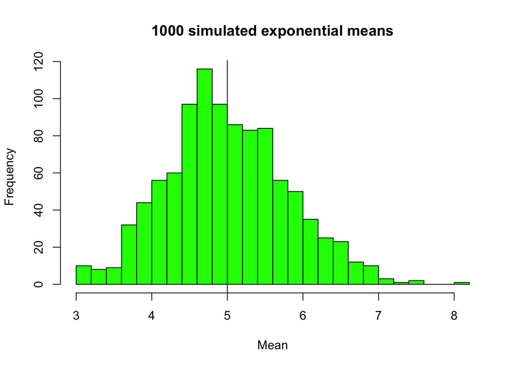

```r
hist(mu, breaks = 20, xlab = "Mean", main = "1000 simulated exponential means", col = "green")
abline(v = mu_CLT, col = "red")
abline(v = mean(mu), col = "blue")
```

Simulated mean is 4.999702, and theoretical mean is 5.

## Sample Variance versus Theoretical Variance:

Include figures (output from R) with titles. Highlight the variances you are comparing. Include text that explains your understanding of the differences of the variances.

```r
# Simulated Variance
print((sd(mu))^2)
```

```
## [1] 0.6432442
```

```r
# Theoretical Variance
print((sd_CLT/sqrt(n))^2)
```

```
## [1] 0.625
```

Simulated variance is 0.6432442, and theoretical variance is 0.625.

## Distribution:

Via figures and text, explain how one can tell the distribution is approximately normal.

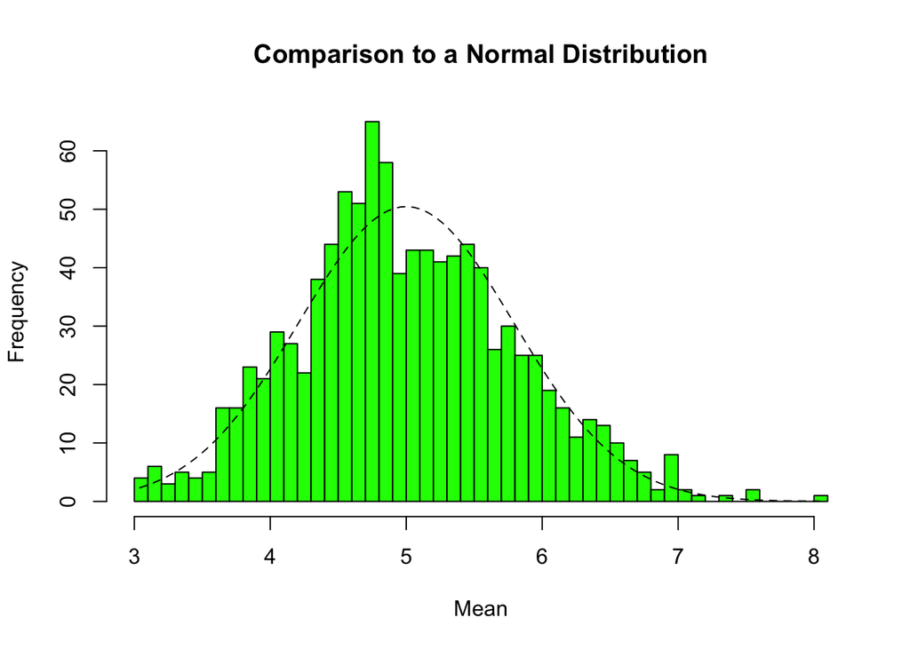

```r
# Plot Histogram
hist(mu, breaks = 40, xlab = "Mean", main = "Comparison to a Normal Distribution", col = "green")

# Add the Theoretical Normal Distribution Line
xfit <- seq(min(mu), max(mu), length = 100)
yfit <- dnorm(xfit, mean = 1/lambda, sd = 1/lambda/sqrt(n))
lines(xfit, yfit*100, lty=2)
```

The fitted line using simulated data is a curve of normal distribution.

As a motivating example, compare the distribution of 1000 exponentials

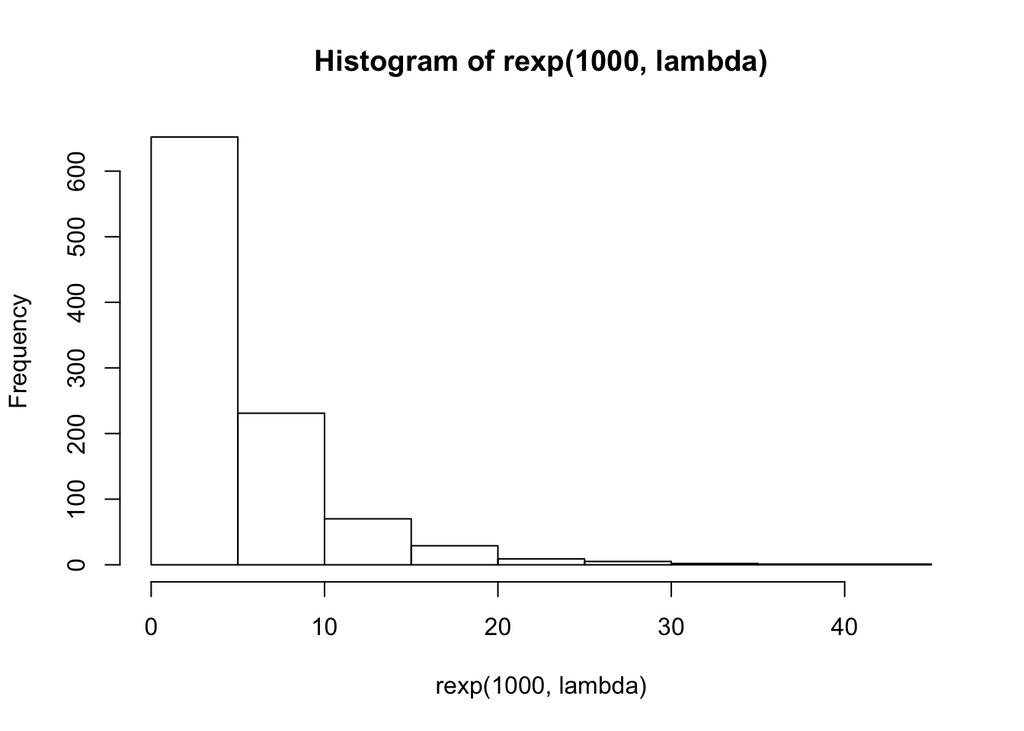

```r
hist(rexp(1000,lambda))
```

and the distribution of 1000 averages of 40 exponentials

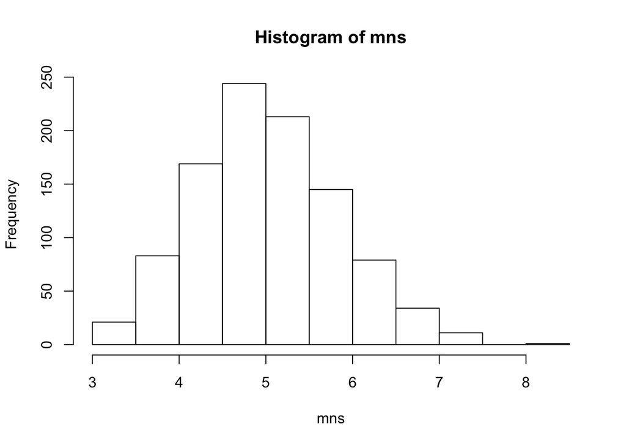

```r
mns = NULL
for (i in 1 : 1000) mns = c(mns, mean(rexp(40,lambda)))
hist(mns)
```

This distribution looks far more Gaussian than the original exponential distribution!

## Part 2 Basic Inferential Data Analysis Instructions

Now in the second portion of the project, we’re going to analyze the ToothGrowth data in the R datasets package.

### 1. Load the ToothGrowth data and perform some basic exploratory data analyses

```r
data<- ToothGrowth
str(data)
```

```
## 'data.frame':    60 obs. of  3 variables:
##  $ len : num  4.2 11.5 7.3 5.8 6.4 10 11.2 11.2 5.2 7 ...
##  $ supp: Factor w/ 2 levels "OJ","VC": 2 2 2 2 2 2 2 2 2 2 ...
##  $ dose: num  0.5 0.5 0.5 0.5 0.5 0.5 0.5 0.5 0.5 0.5 ...
```

```r
head(data,10)
```

```
##     len supp dose
## 1   4.2   VC  0.5
## 2  11.5   VC  0.5
## 3   7.3   VC  0.5
## 4   5.8   VC  0.5
## 5   6.4   VC  0.5
## 6  10.0   VC  0.5
## 7  11.2   VC  0.5
## 8  11.2   VC  0.5
## 9   5.2   VC  0.5
## 10  7.0   VC  0.5
```

```r
names(data)
```

```
## [1] "len"  "supp" "dose"
```

```r
unique(data$len)
```

```
##  [1]  4.2 11.5  7.3  5.8  6.4 10.0 11.2  5.2  7.0 16.5 15.2 17.3 22.5 13.6
## [15] 14.5 18.8 15.5 23.6 18.5 33.9 25.5 26.4 32.5 26.7 21.5 23.3 29.5 17.6
## [29]  9.7  8.2  9.4 19.7 20.0 25.2 25.8 21.2 27.3 22.4 24.5 24.8 30.9 29.4
## [43] 23.0
```

```r
range(data$dose)
```

```
## [1] 0.5 2.0
```

### 2. Provide a basic summary of the data.

The ToothGrowth dataset is a dataframe with 60 objects with 3 variables - len, supp, and dose. len has a range from 4.2 to 33.9, and dose has three unique values: 0.5, 1.0 and 2.0. Supp is a factor variable with 2 levels “OJ” and “VC”.

### 3. Use confidence intervals and/or hypothesis tests to compare tooth growth by supp and dose. (Only use the techniques from class, even if there’s other approaches worth considering)

```r
supp <- unique(data$supp)
s1 <- data$len[data$supp == 'OJ']
s2 <- data$len[data$supp == 'VC']

#find the mean len depending on supply
mean_s <- aggregate(data$len, list(supp = data$supp), mean)
sd_s <- aggregate(data$len, list(supp = data$supp), sd)

n1 <- length(s1)
n2 <- length(s2)
mu1 <- mean_s$x[1]
mu2 <- mean_s$x[2]
sd1 <- sd_s$x[1]
sd2 <- sd_s$x[2]
## Pooled std
sd <- ((n1-1)*sd2^2 + (n2-1)*sd1^2)/(n1+n2-2)
pval <- pt((mu1-mu2)/(sd*(1/n1+1/n2)^.5), df = n1+n2-2)
pval
```

```
## [1] 0.6005653
```

p value is 0.6, null hypothesis isn’t rejected, so the two suppplies doesn’t make a difference in tooth growth in terms of length.

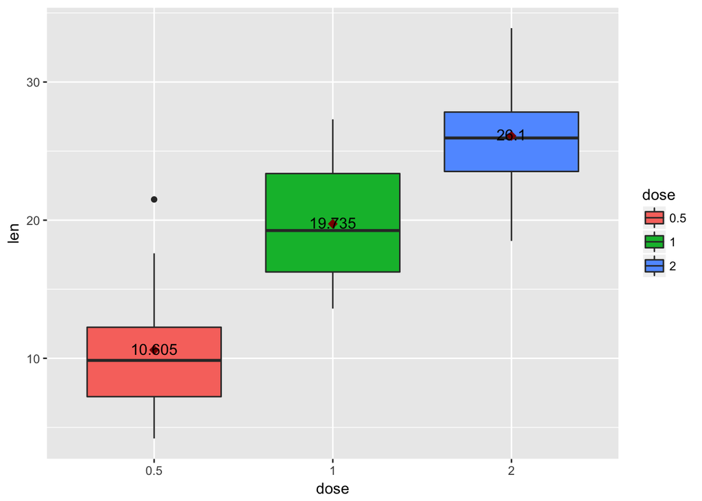

```r
# Convert dose into a factor
data$dose <- factor(data$dose)
mean_d <- aggregate(len ~ dose, data, mean)
sd_d <- aggregate(data$len, list(dose = data$dose), sd)

library(ggplot2)
ggplot(data=data, aes(x=dose, y=len, fill=dose)) + geom_boxplot() +
  stat_summary(fun.y=mean, colour="darkred", geom="point",
               shape=18, size=3,show.legend = FALSE) +
  geom_text(data = mean_d, aes(label = len, y = len + 0.08))
```

```r
mu <- mean_d$len[1]
sd <- sd_d$x[1]
n <- sum(data$dose == 0.5)
CI <- mu + c(-1,1)*qt(.975, n-1)*sd/sqrt(n)
CI1 <- CI

mu <- mean_d$len[2]
sd <- sd_d$x[2]
n <- sum(data$dose == 1)
CI <- mu + c(-1,1)*qt(.975, n-1)*sd/sqrt(n)
CI2 <- CI

mu <- mean_d$len[3]
sd <- sd_d$x[3]
n <- sum(data$dose == 2)
CI <- mu + c(-1,1)*qt(.975, n-1)*sd/sqrt(n)
CI3 <- CI

CI1
```

```
## [1]  8.499046 12.710954
```

```r
CI2
```

```
## [1] 17.66851 21.80149
```

```r
CI3
```

```
## [1] 24.33364 27.86636
```

Under dose 0.5, tooth length has a 95% CI 8.5 to 12.7; Under dose 1.0, tooth length has a 95% CI 17.7 to 21.8; Under dose 2.0, tooth has a 95% CI 24.3 to 27.9.

### 4. State your conclusions and the assumptions needed for your conclusion

Conclusion:

p-value comparing the two supplies is 0.6, and it indicates no significant difference to tooth growth using the two supplies.

The three confidence intervals of tooth length under different dose levels are separable. This shows that dose is a key factor to tooth growth. Higher dose, faster growth.

Assumption:

The assumption of making the conclusion is that the two factors “supply” and “dose” are independent, and the samples investigated are representative of the population.